# Bayes’ Theorem And The Importance Of Sensitivity and Specificity In Medical Tests

[Return to Homepage](https://mathiassteilen.github.io/)

[Return to Probability Riddles Section](https://mathiassteilen.github.io/simulation.html)

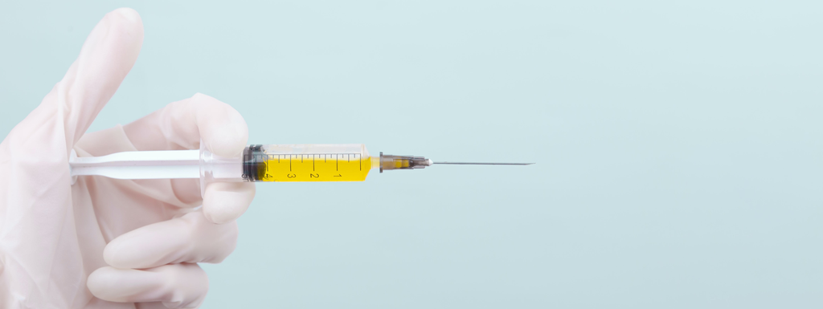

### What Are We Looking At?

Suppose that a test for an illness is 99% sensitive and 99% specific. That is, the test will produce 99% true positive results for sick patients and 99% true negative results for healthy patients. Suppose that 0.05% of people exhibit this illness. What is the probability that a randomly selected individual with a positive test is indeed sick?

This probability problem introduces uncertainty about the test’s capability of identifying the true state of the tested patient. Given that the test is not correct 100% of the time, how accurate should it be?

### Simulation

```r
#params
resmat <- matrix(nrow = 10000, ncol = 7)
colnames(resmat) <- c("P(D)", "P(D_bar)", "P(T|D)", "P(T_bar|D)", "P(T|D_bar)", "P(T_bar|D_bar)", "P(D|T)")

prob_sick <- 0.0005
lower_precision <- 0.95
upper_precision <- 1

#populate matrix
resmat[,"P(D)"] <- prob_sick
resmat[,"P(D_bar)"] <- 1 - resmat[,1]
resmat[,"P(T|D)"] <- seq(from = lower_precision, to = upper_precision, length.out = nrow(resmat))
resmat[,"P(T_bar|D)"] <- 1 - resmat[,"P(T|D)"]
resmat[,"P(T_bar|D_bar)"] <- seq(from = lower_precision, to = upper_precision, length.out = nrow(resmat))
resmat[,"P(T|D_bar)"] <- 1 - resmat[,"P(T_bar|D_bar)"]
resmat[,"P(D|T)"] <- (resmat[,"P(T|D)"] * resmat[,"P(D)"])/(resmat[,"P(T|D)"] * resmat[,"P(D)"] + resmat[,"P(D_bar)"] * resmat[,"P(T|D_bar)"])

resmat %>%
  as_tibble()
```

| P(D) | P(D_bar) | P(T\|D) | P(T_bar\|D) | P(T\|D_bar) | P(T_bar\|D_bar) | P(D\|T) |
| --- | --- | --- | --- | --- | --- | --- |
| 5e-04 | 0.9995 | 0.9500000 | 0.0500000000 | 0.0500000000 | 0.9500000 | 0.009415263 |
| 5e-04 | 0.9995 | 0.9500050 | 0.0499949995 | 0.0499949995 | 0.9500050 | 0.009416245 |
| 5e-04 | 0.9995 | 0.9500100 | 0.0499899990 | 0.0499899990 | 0.9500100 | 0.009417227 |
| 5e-04 | 0.9995 | 0.9500150 | 0.0499849985 | 0.0499849985 | 0.9500150 | 0.009418209 |
| 5e-04 | 0.9995 | 0.9500200 | 0.0499799980 | 0.0499799980 | 0.9500200 | 0.009419192 |
| 5e-04 | 0.9995 | 0.9500250 | 0.0499749975 | 0.0499749975 | 0.9500250 | 0.009420174 |
| 5e-04 | 0.9995 | 0.9500300 | 0.0499699970 | 0.0499699970 | 0.9500300 | 0.009421157 |
| 5e-04 | 0.9995 | 0.9500350 | 0.0499649965 | 0.0499649965 | 0.9500350 | 0.009422140 |
| 5e-04 | 0.9995 | 0.9500400 | 0.0499599960 | 0.0499599960 | 0.9500400 | 0.009423124 |
| 5e-04 | 0.9995 | 0.9500450 | 0.0499549955 | 0.0499549955 | 0.9500450 | 0.009424107 |

[output cut: 9990 more lines]

Using Bayes’ theorem, the probability of actually being sick after being diagnosed positively can be retrieved.

### Plotting The Results

The plot below shows the probability of actually being sick with the aforementioned disease after being given a positive test result. The x-axis shows the test sensitivity and specificity on a continuous interval in the upper 5% range.

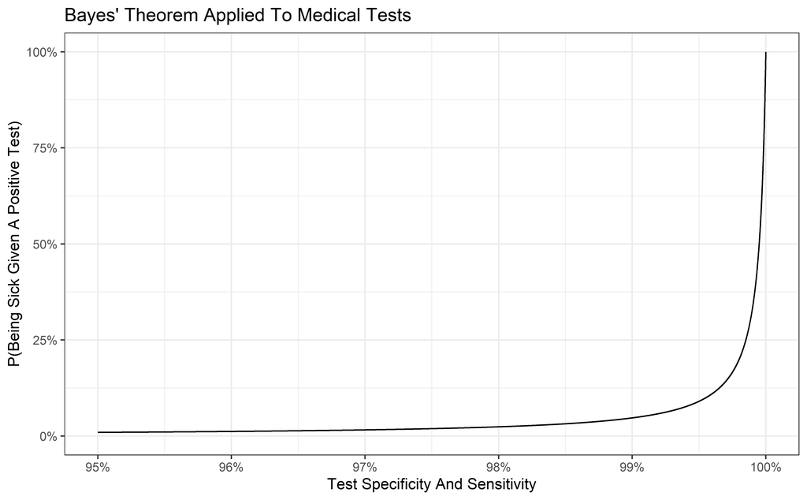

```r
resmat %>%
  as_tibble() %>%
  ggplot(aes(x = `P(T|D)`, y = `P(D|T)`)) +
  geom_line() +
  labs(y = "P(Being Sick Given A Positive Test)",
       x = "Test Specificity And Sensitivity",
       title = "Bayes' Theorem Applied To Medical Tests") +
  scale_y_continuous(labels = scales::percent_format(accuracy = 1),
                     limits = c(0,1)) +
  scale_x_continuous(labels = scales::percent_format(accuracy = 1)) +
  theme_bw()
```

It quickly becomes apparent, that the sense of security from seemingly high accuracy of medical tests quickly wanes when looking at the posterior probability of actually being sick. The way out of this dilemma are either higher parameters of sensitivity and specificity or simply testing multiple times, as has been shown by COVID-19 rapid tests over the course of the pandemic.

A work by [Mathias Steilen](https://www.linkedin.com/in/mathias-steilen/)